# Trabajo Grupal R

Afrania

Diana Obregón

José G.

Leonel Figueroa

22 Enero 2023

# *Análisis espacial a nivel regional de los recursos transferidos del Gobierno Nacional a los Gobiernos Locales durante pandemia en el año 2020*

## Antecedentes y estado del arte

Los datos geoespaciales, conocidos como “shapefiles” contienen datos espaciales de representación vectorial. Estos almacenan información de la ubicación de distintas entidades geográficas, la cual se puede representar con puntos, lineas o polígonos. En ese sentido, el paquete “ggplot2”es utilizado para la generación de mapas visualmente atractivos a partir de información geográfica almacenada en un archivo “shapefile”, en el caso peruano delimitado a nivel departamental, provincial y distrital.

## Metodología

> 1. Data:

**PROYECTOS REACTIVA PERÚ 1 Y 2:** La base de datos utilizada corresponde a los Proyectos ejecutados por municipalidades distritales y provinciales como parte del Reactiva Perú 1 y 2, el cual fue llevado a cabo por el Ministerio de Vivienda, Construcción y Saneamiento (MVCS).

```r
link <- "https://raw.githubusercontent.com/Diane-12/BD_Pytoreactiva/main/pyto_reactica_12_original_vs2.csv"
bd_reactiva_pyto <- read.csv(link)
str(object=bd_reactiva_pyto)
```

```
## 'data.frame':    526 obs. of  22 variables:
##  $ ID                      : int  220 219 184 504 216 233 199 4 174 5 ...
##  $ CODIGOPAIS              : chr  "PE" "PE" "PE" "PE" ...
##  $ CODIGOENTIDAD           : int  11476 11476 11476 11476 11476 11476 11476 11476 11476 11476 ...
##  $ UBIGEO                  : int  150108 150108 150106 210101 190104 150712 90119 150133 50704 150103 ...
##  $ COD_REGION              : int  150000 150000 150000 210000 190000 150000 90000 150000 50000 150000 ...
##  $ COD_PROVINCIA           : int  150100 150100 150100 210100 190100 150700 90100 150100 50700 150100 ...
##  $ SNIP                    : int  2473768 2473485 2432217 2453959 2470493 111753 2445099 2464086 2408511 2434729 ...
##  $ CUI                     : int  2473768 2473485 2432217 2453959 2470493 2098242 2445099 2464086 2408511 2434729 ...
##  $ REGION                  : chr  "Lima Metropolitana" "Lima Metropolitana" "Lima Metropolitana" "Puno" ...
##  $ PROVINCIA               : chr  "Lima" "Lima" "Lima" "Puno" ...
##  $ DISTRITO                : chr  "Chorrillos" "Chorrillos" "Carabayllo" "Puno" ...
##  $ PROYECTO                : chr  "CREACION DEL SERVICIO DE ESPACIOS PÚBLICOS DE RECREACIÓN EN PARQUE INFANTIL EN LA UP. ARIA LAS DELICIAS DE VILL"| __truncated__ "CREACION DEL SERVICIO DE ESPACIOS PUBLICOS VERDES EN LA UP. ARIA LAS DELICIAS DE VILLA ZONA I CHORRILLOS DEL DI"| __truncated__ "CREA…
##  $ DISPOSITIVOLEGAL        : chr  "DU N° 070-2020  " "DU N° 070-2020  " "DU N° 070-2020  " "DU N° 114-2020  " ...
##  $ AMBITO                  : chr  "URBANO" "URBANO" "URBANO" "URBANO" ...
##  $ UNIDADEJECUTORA         : chr  "MUNICIPALIDAD DISTRITAL DE CHORRILLOS" "MUNICIPALIDAD DISTRITAL DE CHORRILLOS" "MUNICIPALIDAD DISTRITAL DE CARABAYLLO" "MUNICIPALIDAD PROVINCIAL DE PUNO" ...
##  $ TOTALEMPLEOS            : int  9 11 101 6 11 141 8 7 8 8 ...
##  $ POBLACIONBENEFICIARIA   : int  5035 5035 4514 811 107 216 910 1857 7342 479 ...
##  $ TIPOLOGIA               : chr  "Equipamiento Urbano" "Equipamiento Urbano" "Pista y Vereda" "Equipamiento Urbano" ...
##  $ TIPOMONEDA              : chr  "PEN" "PEN" "PEN" "PEN" ...
##  $ MONTODEINVERSIÓN        : chr  "297,786.41" "357,242.87" "3,446,429.39" "162,204.69" ...
##  $ MONTODETRANSFERENCIA2020: chr  "18,342.00" "61,045.00" "75,917.00" "153,869.00" ...
##  $ ESTADO                  : chr  "En Ejecución" "Concluido" "Concluido" "Concluido" ...
```

```r
bd_reactiva_pyto <- bd_reactiva_pyto[-c(526), ]
# head(bd_reactiva_pyto,n=5) # Podemos usar esta función visiualizar los 05 primeros elementos de nuestra base de datos
# sapply(bd_reactiva_pyto, class) # Podemos usarla para conocer la clase de cada variable de nuestro base de datos
```

La base de datos muestra información de los Proyectos hasta junio del 2021 y se obtuvo del siguiente [enlace](https://www.datosabiertos.gob.pe/dataset/proyectos-reactiva-per%C3%BA.)

De esta base de datos se recogieron las siguientes variables:

*1. UBIGEO:* Código del distrito donde se ubica el proyecto.

*2. COD_REGION:* Código de la región donde se ubica el proyecto.

*3. COD_PROVINCIA:* Código de la provincia donde se ubica el proyecto.

*4. REGION:* Región donde se ubica el proyecto.

*5. PROVINCIA:* Provincia donde se ubica el proyecto.

*6. TOTALEMPLEOS:* Número de empleos generados con la ejecución del proyecto.

*7. POBLACIONBENEFICIARIA:* Número de población beneficiada con el proyecto.

*8. MONTODEINVERSIÓN:* Monto total de inversión del proyecto.

*9. MONTODETRANSFERENCIA2020:* Monto transferido al gobierno local en el periodo 2020.

*10. ESTADO:* Etapa en la que se encuentra el proyecto.

Adicionalmente, se utilizó una base de datos complementaria para obtener la población de los distritos presentes en la base de datos sobre Proyectos Reactiva Perú.

**POBLACION_2017:** La base de datos incluye información respecto a la población a nivel distrital teniendo como fuente el Censo Nacional 2017 y obteniendo la base de datos del siguiente [enlace](https://censos2017.inei.gob.pe/redatam/.)

La base de datos incluyó las siguientes variables:

*1. UBIGEO:* Código del distrito.

*2. COD_PROVINCIA:* Código de la provincia.

*3. POB_REG:* Suma de la población total de los distritos que tuvieron proyectos ejecutados y concluidos en una determinada región.

*4. POB_PROV:* Suma de la población total de los distritos que tuvieron proyectos ejecutados y concluidos en una determinada provincia.

*5. POB_DIST:* Población total en el distrito.

El conjunto de las variables descritas permitieron la creación de las variables analizadas, siendo estas las siguientes:

*1. DISTRIBUCIÓN DE LOS RECURSOS TRANSFERIDOS:* Suma de los montos transferidos para la ejecución de los proyectos a nivel provincial y regional.

*2. PORCENTAJE DEL COSTO EL PROYECTO CUBIERTO CON RECURSOS TRANSFERIDOS:* Porcentaje del monto ejecutado en el proyecto que fue transferido por el MVCS a los gobiernos locales a nivel regional y provincial.

*5. MONTO DE INVERSIÓN POR TIPO DE INVERSIÓN:* Montos de inversión dirigidos a los tipos de inversión, ya sean estos para equipamiento urbano, pistas y veredas, o puentes.

> 2. Procesamiento:

DISTRIBUCIÓN DE LOS RECURSOS TRANSFERIDOS: En primer lugar, se creó una tabla con la suma de los montos transferidos para cada proyecto, agrupando estos por regiones. Además, se creó una fila para la región Madre de Dios, ya que esta no existía en la base de datos principal (PROYECTOS REACTIVA PERÚ 1 Y 2), generando esto que la región no quede solo como espacio vacío en la visualización. Luego, se creó un nuevo data frame uniendo la base de datos principal y la tabla con los montos transferidos por región. Con esto, se pudo obtener la visualización de la variable como mapa. El mismo procedimiento se realizó para la obtención del mapa para la visualización de los montos transferidos a nivel provincial, creando una tabla de suma de monto de transferencias por provincia y agregando 68 filas para las 68 provincias que no existían en la base de datos principal.

PORCENTAJE DEL COSTO EL PROYECTO CUBIERTO CON RECURSOS TRANSFERIDOS: Para este análisis, se generó una variable que calculaba el porcentaje que representa la variable “MONTODETRANSFERENCIA2020” respecto a la variable “MONTODEINVERSIÓN”. Posteriormente, realizó el procedimiento de generar una tabla que sacará el promedio de los porcentajes por región; luego, se agregó la fila para la región de Madre de Dios y se creó un nuevo data frame a partir de la base principal y la tabla.

- Cambiamos la clase de aquellas variables de clase **‘character’** que nos interesan a **‘numeric’** . En este caso nos referimos a *MONTODETRANSFERENCIA2020* y *MONTODEINVERSION*. Con la función **stra_remove_all** removemos todas las ‘,’ de los valores de nuestras variables y procedemos a hacer la conversión de clase a numérico.

```r
bd_reactiva_pyto$MONTODETRANSFERENCIA2020 <- str_remove_all(bd_reactiva_pyto$MONTODETRANSFERENCIA2020, ",")
bd_reactiva_pyto$MONTODETRANSFERENCIA2020 <- as.numeric(bd_reactiva_pyto$MONTODETRANSFERENCIA2020)

bd_reactiva_pyto$MONTODEINVERSIÓN <- str_remove_all(bd_reactiva_pyto$MONTODEINVERSIÓN, ",")
bd_reactiva_pyto$MONTODEINVERSIÓN <- as.numeric(bd_reactiva_pyto$MONTODEINVERSIÓN)

class(bd_reactiva_pyto$MONTODETRANSFERENCIA2020)
```

```
## [1] "numeric"
```

```r
class(bd_reactiva_pyto$MONTODEINVERSIÓN)
```

```
## [1] "numeric"
```

- Generamos el objeto **reg_mont_transf**, una tabla que presenta el monto total transferido por regiones.

```r
reg_mont_transf <- bd_reactiva_pyto %>%
  group_by(REGION) %>%
  summarise(Suma=sum(MONTODETRANSFERENCIA2020)) %>%
  View()
```

> 3. Técnica y Algoritmos aplicados:

Paquetes y Librerias a utilizar (LEONEL)

```r
install.packages("reshape2")

#install.packages("sf")
library(sf)

#install.packages("readr")
library(readr)

#install.packages("stringr")
library(stringr)
#Se usará la función "str_remove_all()"

#install.packages("remotes")
library(remotes)

#install.packages("Rtools")

#install.packages("ggplot2")
library(ggplot2)

#install.packages("magrittr")
library(magrittr)

#install.packages("dplyr")
library(dplyr)

#install.packages("mapsPERU")
library(mapsPERU)


library(naniar)
# Se usarán las funciones miss_var_summary

#install_github("musajajorge/mapsPERU")
```

## Discusión

En el 2020, el gobierno peruano, mediante el Decreto de Urgencia N° 070-2020, establece medidas extraordinarias para la reactivación económica ante la emergencia sanitaria producida por el COVID 19, en materia de inversiones, gasto corriente y otras actividades para la generación de empleo. Posteriormente, se sumaron el Decreto de Urgencia N° 114-2020 y el Decreto Supremo N.° 262-2020-EF, en los cuales se reafirma que los gobiernos regionales y locales, en el marco de sus competencias, implementen la ejecución de acciones oportunas para la reactivación de la actividad económica, fomentando el trabajo local a través del empleo de mano de obra especializada y no especializada.

Con dicho objetivo, se autorizaron la transferencia de partidas en el Presupuesto Público para el año fiscal 2020 a favor de diversos gobiernos locales para financiar la ejecución de proyectos de inversión e Inversiones de Optimización, de Ampliación Marginal, de Rehabilitación y de Reposición en materia de vías urbanas, planeamiento urbano y rural y conservación y ampliación de las áreas verdes y ornato público y saneamiento urbano y rural.

Por otro lado, la inversión pública en América Latina y el Caribe (ALC), ha sido severamente afectada debido a la pandemia ocasionada por el COVID 19. El nivel promedio de inversión pública alcanzó un 3,6% del PBI, uno de los más bajos en una década; asimismo el índice de gestión de la inversión pública reporta un 2.5 de 4 puntos posibles, lo que indica una baja eficiencia (Armendariz, 2020). Sumado a lo anterior, según una investigación efectuada por el (BID, 2020), se muestra que el gasto público en la región revela un desperdicio generalizado de hasta 4,4 % del PBI de la región. En ese sentido, resulta necesario que se optimice la inversión pública mediante criterios técnicos y transparentes de priorización que a su vez generen crecimiento y empleo, ya que estos son vitales durante el periodo de reactivación económica.

En este contexto, el uso de mapas es un medio utilizado para reportar estadísticas oficiales producidas por instituciones del gobierno central con el fin de hacerlas más digeribles para el lector. Ejemplo de ello es el documento producido por el INEI “Mapa de pobreza monetaria provincial y distrital 2018”, el cual contiene indicadores de pobreza[^1], desagregada geográficamente a nivel de provincial y distrital, la cual constituye por su naturaleza un importante insumo para la priorización y la implementación de políticas sociales en los distritos más vulnerables del país (INEI, 2018).

### Visualización de la data:

** Asignamos nuestra base de datos a un objeto.

```r
library(mapsPERU)
df <- map_REG
df
```

```
## # A tibble: 26 × 5
##    COD_REGION REGION       coords_x coords_y                            geometry
##    <chr>      <chr>           <dbl>    <dbl>                  <MULTIPOLYGON [°]>
##  1 010000     Amazonas        -78.1    -5.07 (((-77.59734 -6.032264, -77.59581 …
##  2 020000     Áncash          -77.7    -9.41 (((-78.17101 -8.500004, -78.18356 …
##  3 030000     Apurímac        -73.0   -14.0  (((-72.3994 -13.64069, -72.39879 -…
##  4 040000     Arequipa        -72.5   -15.8  (((-74.84317 -15.56497, -74.82033 …
##  5 050000     Ayacucho        -74.1   -14.1  (((-74.34595 -12.17374, -74.34618 …
##  6 060000     Cajamarca       -78.7    -6.43 (((-79.29619 -7.129617, -79.30373 …
##  7 070000     Callao          -77.1   -11.9  (((-77.15692 -12.06896, -77.15325 …
##  8 080000     Cusco           -72.2   -13.2  (((-71.51004 -15.00353, -71.50725 …
##  9 090000     Huancavelica    -75.0   -13.0  (((-74.28611 -12.77462, -74.29302 …
## 10 100000     Huánuco         -76.0    -9.42 (((-76.911 -9.368459, -76.91706 -9…
## # … with 16 more rows
```

- Genero una tabla que presenta por región el monto de transferencia.

```r
tabla <- bd_reactiva_pyto %>%
  group_by(REGION) %>%
  summarise(Suma=sum(MONTODETRANSFERENCIA2020))
```

- Artificio: Creando una fila adicional porque no existe en nuestra BBDD.

```r
nuevafila = data.frame(REGION="Madre de Dios", Suma=0)
tabla = rbind(tabla,nuevafila)
```

- Merge entre TABLA y df1 (BBDD con las locaciones, regiones, provincias, etc.).

```r
library(dplyr)
library(sf)
df1 <- left_join(df, tabla, by="REGION")
str(tabla)
```

```
## tibble [26 × 2] (S3: tbl_df/tbl/data.frame)
##  $ REGION: chr [1:26] "Amazonas" "Áncash" "Apurímac" "Arequipa" ...
##  $ Suma  : num [1:26] 3.50e+07 1.67e+07 4.92e+07 1.72e+07 1.08e+08 ...
```

- Generación del mapa por región.

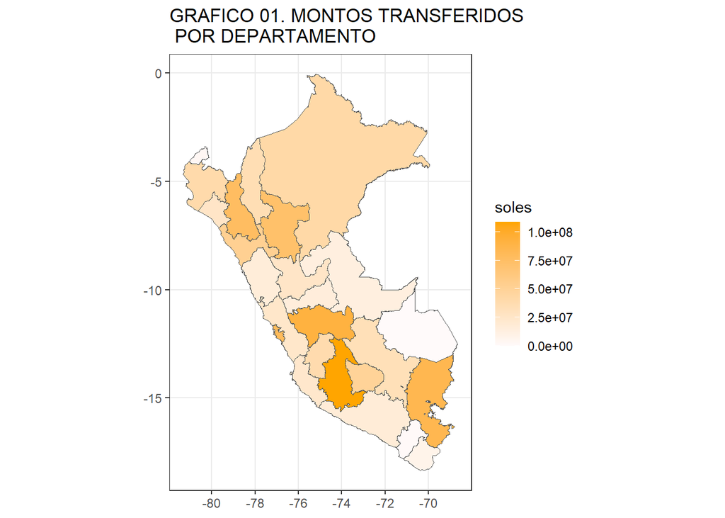

```r
library(ggplot2)
library(sf)


ggplot(df1, aes(geometry=geometry)) +
  geom_sf(aes(fill=Suma)) +
  theme_bw() +
  labs(fill = "soles") +
  labs(title = "GRAFICO 01. MONTOS TRANSFERIDOS \n POR DEPARTAMENTO") +
  scale_fill_gradient (low="snow", high="orange")
```

```r
#Anexo: Página de colores --> https://r-charts.com/es/colores/
```

> Distribución de los recursos transferidos por provincia
- Mapa con la distribución de recursos por provincia.

```r
library(mapsPERU)
df2 <- map_PROV
```

- Genero una tabla que presenta por provincia el monto de transferencia.

```r
TABLA2 <-bd_reactiva_pyto %>%
  group_by(COD_PROVINCIA) %>%
  summarise(suma=sum(MONTODETRANSFERENCIA2020))
```

- Artificio: creando varias filas adicionales (68) porque no existen en nuestra BBDD de Reactiva.

```r
nuevafilas=data.frame(COD_PROVINCIA=c("010400", "010600", "020100", "020200", "020300", "020400", "020700", "020900", "021100", "021200", "021300", "021400", "021500", "021700", "022000", "030100", "030500", "040300", "040400", "040500", "040600", "040700", "040800", "050800", "061200", "080200", "080400", "080500", "080600", "081000", "081100", "081200", "081300", "100600", "100700", "100900", "101000", "110200", "110300", "110400", "120700", "120800", "130300", "130500", "130700", "130800", "140200", "150300", "150900", "160300", "160500", "160800", "170100", "170200", "170300", "180100", "180200", "190200", "200800", "210400", "220200", "230200", "230300", "230400", "240200", "250200", "250300", "250400"), suma=c(0, 0, 0, 0, 0, 0, 0, 0, 0, 0, 0, 0, 0, 0, 0, 0, 0, 0, 0, 0, 0, 0, 0, 0, 0, 0, 0, 0, 0, 0, 0, 0, 0, 0, 0, 0, 0, 0, 0, 0, 0, 0, 0, 0, 0, 0, 0, 0, 0, 0, 0, 0, 0, 0, 0, 0, 0, 0, 0, 0, 0, 0, 0, 0, 0, 0, 0, 0))

TABLA2=rbind(TABLA2,nuevafilas)
```

- Merge entre TABLA2 y df2 (BBDD con las locaciones, regiones, provincias, etc.).

```r
library(dplyr)
library(sf)
df2 <- left_join(df2, TABLA2, by="COD_PROVINCIA")
str(TABLA2)
```

```
## tibble [196 × 2] (S3: tbl_df/tbl/data.frame)
##  $ COD_PROVINCIA: chr [1:196] "10100" "10200" "10300" "10500" ...
##  $ suma         : num [1:196] 4177586 16546325 5876360 3872595 4487606 ...
```

- Generación del mapa por provincia.

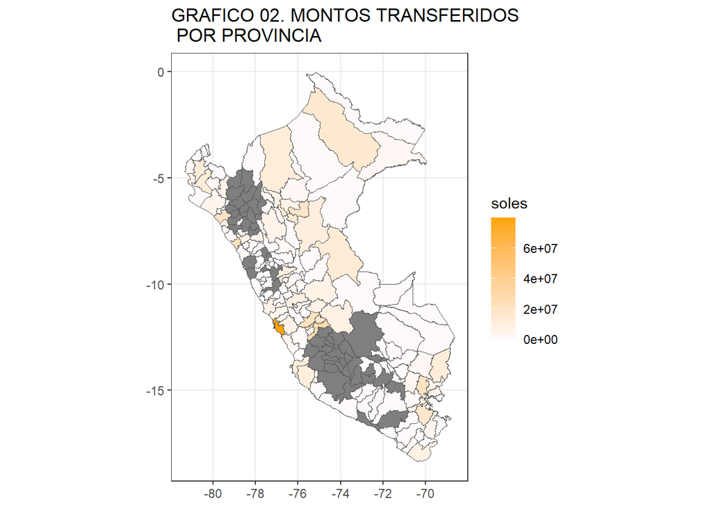

```r
library(ggplot2)
ggplot(df2, aes(geometry=geometry)) +
  geom_sf(aes(fill=suma)) +
  theme_bw() +
  geom_sf(aes(fill=suma)) +
  labs(fill = "soles") +
  labs(title = "GRAFICO 02. MONTOS TRANSFERIDOS \n POR PROVINCIA") +
  scale_fill_gradient (low="snow", high="orange")
```

> Mapa con la distribución de recursos por región:
- Creamos una columna adicional con el porcentaje del costo del proyecto cubierto por recursos transferidos.

```r
bd_reactiva_pyto <- cbind(bd_reactiva_pyto, PorcCostoAsumido=c(bd_reactiva_pyto$MONTODETRANSFERENCIA2020 / bd_reactiva_pyto$MONTODEINVERSIÓN))
```

```r
TABLA3 <-bd_reactiva_pyto %>%
  group_by(REGION) %>%
  summarise(PromedioPorceAsumido=mean(PorcCostoAsumido))
```

- Artificio: Creando una fila adicional porque no existe en nuestra BBDD.

```r
nuevafila3=data.frame(REGION="Madre de Dios", PromedioPorceAsumido=NA)
TABLA3=rbind(TABLA3,nuevafila3)
```

- Merge entre TABLA y df1 (BBDD con las locaciones, regiones, provincias, etc.).

```r
library(dplyr)
library(sf)
df3 <- left_join(df, TABLA3, by="REGION")
str(TABLA3)
```

```
## tibble [26 × 2] (S3: tbl_df/tbl/data.frame)
##  $ REGION              : chr [1:26] "Amazonas" "Áncash" "Apurímac" "Arequipa" ...
##  $ PromedioPorceAsumido: num [1:26] 0.909 0.925 0.831 0.936 0.941 ...
```

- Generación del mapa por región.

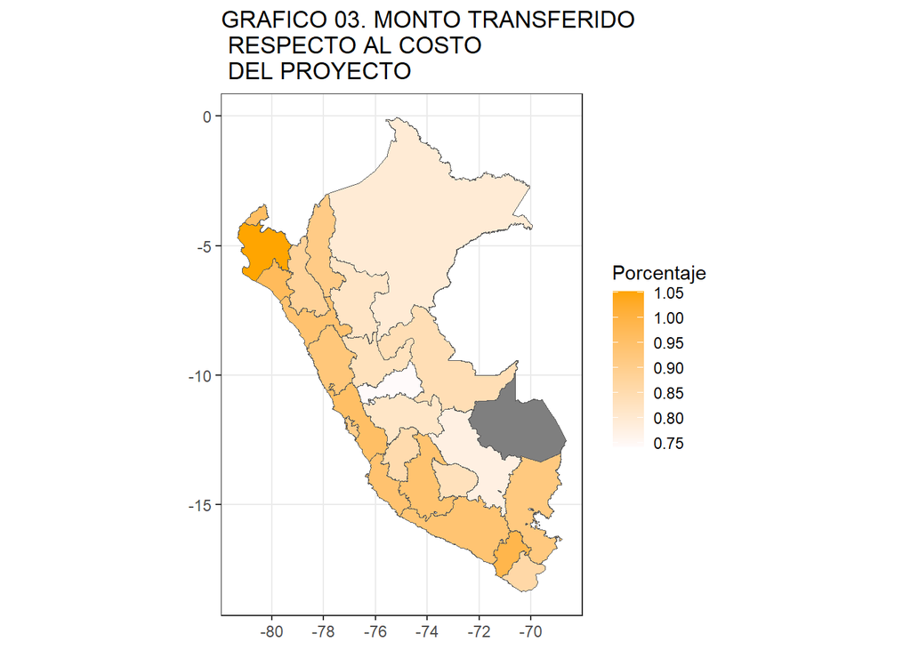

```r
library(ggplot2)

ggplot(df3, aes(geometry=geometry)) +
  geom_sf(aes(fill=PromedioPorceAsumido)) +
  theme_bw() +
  labs(fill = "Porcentaje ")+
  labs(title = "GRAFICO 03. MONTO TRANSFERIDO \n RESPECTO AL COSTO \n DEL PROYECTO")+
  #theme(plot.title = element_text(hjust = 0.5)) +
  scale_fill_gradient (low="snow", high="orange")
```

> Porcentaje del costo del proyecto cubierto por recursos transferidos. (región)

> Número de Proyectos por tipo de intervención.

[figure not shown]

```r
bd_reactiva_pyto %>%
  group_by(TIPOLOGIA) %>%
  summarise(count=n()) %>%
  ggplot(aes(x=reorder(TIPOLOGIA, (-count)), y=count)) +
  geom_col(colour="black") +
  geom_bar(stat = "identity", fill="orange", color="grey40") +
  theme_bw() +
  #coord_flip() +
  geom_text(aes(label=after_stat(y), fontface= "bold"), vjust=-0.2) +
  theme(legend.title = element_blank()) +
  labs(x=" ", y=" ", title = "GRAFICO 04. NÚMERO DE PROYECTOS POR TIPO", subtitle= "Millones de soles")
```

[figure not shown]

```r
bd_reactiva_pyto %>%
  group_by(TIPOLOGIA) %>%
  summarise(SOLES=sum(MONTODETRANSFERENCIA2020)) %>%
  ggplot(aes(x=reorder(TIPOLOGIA, (-SOLES)), y=SOLES, fill=TIPOLOGIA)) +
  geom_col(colour="black") +
  geom_bar(stat = 'identity', fill="orange", color="grey40") +
  theme_bw() +
  geom_text(aes(label=scales::comma(round(SOLES/1000), accuracy = 1), fontface="bold"), vjust=-0.2) +
  #scale_y_continuous(labels = label_dollar())
  labs(x=" ", y=" ", title = "GRAFICO 05. MONTOS TRANSFERIDOS POR TIPO DE PROYECTO", subtitle= "Millones de soles") +
  theme(legend.position = "none") +
  theme(axis.text.y=element_blank(), axis.ticks.y=element_blank())
```

> Monto transferido y costo de Proyecto por tipo de intervención.

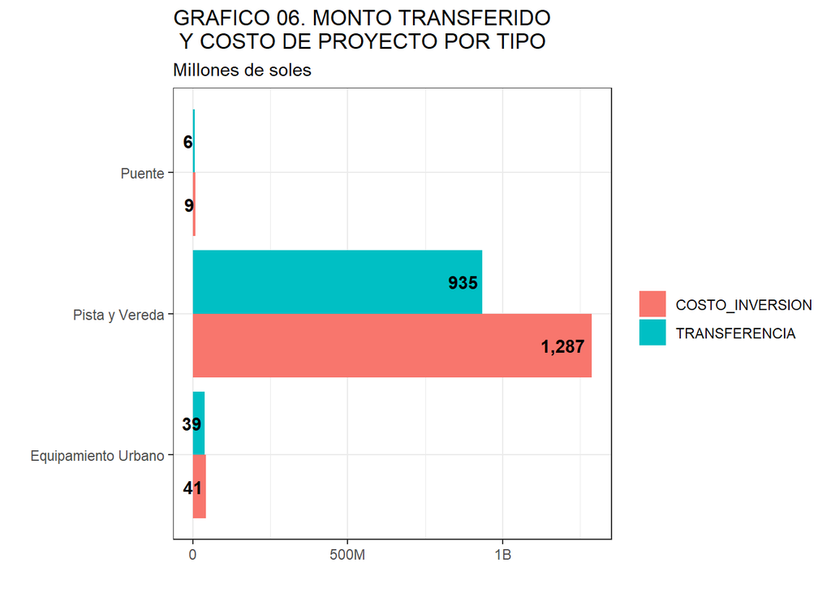

```r
library(ggplot2)
#install.packages("ggplot")
#library(ggplot)
library(reshape2)
#install.packages("magrittr")
library(tidyr)
#install.packages("scales")
library(scales)
library(dplyr)


#Creación de tabla de resumen:
TABLA4 <-bd_reactiva_pyto %>%
  group_by(TIPOLOGIA) %>%
  summarise(TRANSFERENCIA=sum(MONTODETRANSFERENCIA2020), COSTO_INVERSION=sum(MONTODEINVERSIÓN))
View(TABLA4)

View(bd_reactiva_pyto)

#Creación de gráfico

df_1 <- TABLA4 |>
  pivot_longer(cols = TRANSFERENCIA:COSTO_INVERSION, names_to= "soles", values_to = "valor" )
#View(df_1)

ggplot(df_1, aes(x=TIPOLOGIA, y=valor, fill=soles)) +
  geom_bar(position = position_dodge(width=0.9), stat="identity") +
  geom_text(aes(label=scales::comma(round(valor/1000000)), hjust=1.15,  fontface="bold"), position=position_dodge(width=0.9) ) +
  theme_bw() +
  scale_y_continuous(label = label_number_si()) +
  theme(legend.title = element_blank()) +
  labs(x=" ", y=" ", title = "GRAFICO 06. MONTO TRANSFERIDO \n Y COSTO DE PROYECTO POR TIPO", subtitle= "Millones de soles") +
  coord_flip()
```

## Referencias:

Notas:

Bibliografía:

Armendariz, E. (Junio de 2020). Hacer más con menos: Recomendaciones para mejorar la inversión pública en la post-pandemia. Obtenido de https://blogs.iadb.org/gestion-fiscal/es/hacer-mas-con-menos-recomendaciones-inversion-publica/

BID. (2020). Estudio BID-OCDE instan a fortalecer gobernanza e integridad en América Latina y el Caribe. Obtenido de https://www.iadb.org/es/noticias/estudio-bid-ocde-instan-fortalecer-gobernanza-e-integridad-en-america-latina-y-el-caribe

INEI. (2018). Mapa de Pobreza monetaria provincial y distrital . Lima.

[^1]: Elaborados con una metodología que combina datos del Censo de Población y Vivienda 2017 (CPV), la Encuesta Nacional de Hogares 2017-2018 (ENAHO) y otras fuentes de datos.